# Clustering with the Leiden Algorithm on Multiplex Graphs

## Clustering with the Leiden Algorithm on Multiplex Graphs

The Leiden R package supports calling built-in methods for Multiplex graphs. This vignette assumes you already have the 'leiden' package installed. See the other vignettes for details.

## Set up

First we import the functions required in the package.

```r
library("leiden")
```

We also require a example multiplex graph. Here we import a dataset from the 'mplex' package (bear in mind this is a remote package not available on CRAN).

```r
remotes::install_github("Achab94/mplex")
multiplex_graph <- mplex::aarhus_mplex
multiplex_graph
```

```
#> $lunch
#> IGRAPH f96ee8a DN-- 61 193 --
#> + attr: name (v/c)
#> + edges from f96ee8a (vertex names):
#>  [1] U102->U139 U102->U33  U22 ->U26  U22 ->U41  U22 ->U42  U22 ->U49  U26 ->U41  U26 ->U42  U26 ->U49  U29 ->U32
#> [11] U29 ->U17  U29 ->U14  U32 ->U17  U32 ->U130 U32 ->U14  U32 ->U73  U41 ->U42  U42 ->U49  U42 ->U47  U59 ->U91
#> [21] U59 ->U126 U59 ->U110 U59 ->U53  U59 ->U65  U59 ->U67  U59 ->U72  U97 ->U71  U97 ->U126 U97 ->U37  U97 ->U4
#> [31] U97 ->U69  U97 ->U6   U124->U109 U124->U126 U124->U47  U124->U99  U17 ->U14  U17 ->U23  U17 ->U73  U71 ->U4
#> [41] U71 ->U67  U71 ->U63  U86 ->U130 U91 ->U126 U91 ->U110 U91 ->U53  U91 ->U65  U91 ->U67  U91 ->U72  U109->U126
#> [51] U109->U134 U109->U18  U109->U3   U109->U47  U109->U54  U109->U62  U109->U76  U109->U79  U109->U90  U109->U99
#> [61] U126->U54  U126->U90  U126->U37  U126->U110 U126->U113 U126->U138 U126->U72  U126->U69  U126->U6   U130->U134
#> [71] U130->U79  U130->U4   U130->U110 U134->U54  U134->U62  U134->U76  U134->U79  U134->U90  U134->U99  U134->U13
#> + ... omitted several edges
#>
#> $facebook
#> IGRAPH e4aeb68 DN-- 61 127 --
#> + attr: name (v/c)
#> + edges from e4aeb68 (vertex names):
#>  [1] U29 ->U32  U29 ->U91  U32 ->U71  U32 ->U91  U32 ->U130 U32 ->U4   U32 ->U110 U32 ->U67  U42 ->U49  U42 ->U79
#> [11] U42 ->U142 U59 ->U91  U59 ->U110 U59 ->U113 U59 ->U67  U124->U91  U124->U109 U124->U130 U124->U134 U124->U18
#> [21] U124->U3   U124->U47  U124->U54  U124->U76  U124->U79  U124->U69  U124->U6   U71 ->U79  U71 ->U4   U71 ->U110
#> [31] U71 ->U67  U91 ->U79  U91 ->U10  U91 ->U142 U91 ->U4   U91 ->U110 U91 ->U113 U91 ->U65  U91 ->U67  U91 ->U69
#> [41] U109->U18  U109->U47  U109->U54  U109->U76  U109->U79  U130->U134 U130->U18  U130->U3   U130->U47  U130->U76
#> [51] U130->U79  U130->U142 U130->U4   U130->U67  U18 ->U3   U18 ->U47  U18 ->U54  U18 ->U76  U18 ->U79  U3  ->U47
#> [61] U3  ->U54  U3  ->U76  U3  ->U79  U47 ->U54  U47 ->U76  U47 ->U79  U47 ->U142 U47 ->U4   U54 ->U76  U54 ->U79
#> [71] U54 ->U10  U54 ->U142 U54 ->U4   U76 ->U79  U76 ->U4   U76 ->U112 U79 ->U142 U79 ->U110 U79 ->U65  U10 ->U142
#> + ... omitted several edges
#>
#> $coauthor
#> IGRAPH 036943b D--- 61 27 --
#> + edges from 036943b:
#>  [1] 10->11 12->13 18->46 23->46 23->49 23->52 26->27 26->28 26->30 26->33 26->36 28->33 30->36 38->54 39->55  4-> 6
#> [17] 46->48 46->49 49->52  6->14  8->37 56->56 57->57 58->58 59->59 60->60 61->61
#>
#> $leisure
#> IGRAPH 459ff32 DN-- 61 88 --
#> + attr: name (v/c)
#> + edges from 459ff32 (vertex names):
#>  [1] U22 ->U42  U29 ->U32  U29 ->U126 U42 ->U49  U42 ->U79  U42 ->U142 U59 ->U91  U59 ->U110 U59 ->U65  U59 ->U72
#> [11] U124->U91  U124->U126 U124->U18  U124->U99  U17 ->U91  U17 ->U14  U17 ->U23  U17 ->U73  U91 ->U126 U91 ->U54
#> [21] U91 ->U90  U91 ->U110 U91 ->U113 U91 ->U138 U91 ->U53  U91 ->U65  U91 ->U72  U91 ->U69  U109->U126 U109->U54
#> [31] U109->U76  U109->U90  U126->U54  U126->U90  U126->U110 U126->U69  U18 ->U62  U18 ->U76  U18 ->U99  U3  ->U54
#> [41] U3  ->U90  U47 ->U76  U54 ->U76  U54 ->U79  U54 ->U90  U54 ->U10  U62 ->U76  U76 ->U79  U76 ->U90  U79 ->U90
#> [51] U79 ->U99  U79 ->U73  U79 ->U65  U90 ->U6   U10 ->U13  U10 ->U142 U10 ->U37  U10 ->U73  U142->U37  U142->U68
#> [61] U106->U41  U106->U118 U14 ->U19  U14 ->U23  U14 ->U73  U19 ->U23  U19 ->U73  U23 ->U73  U4  ->U67  U110->U113
#> [71] U110->U138 U110->U65  U110->U67  U113->U138 U113->U65  U138->U72  U107->U32  U107->U17  U107->U91  U65 ->U72
#> + ... omitted several edges
#>
#> $work
#> IGRAPH 99a1c33 DN-- 61 194 --
#> + attr: name (v/c)
#> + edges from 99a1c33 (vertex names):
#>  [1] U22 ->U26  U22 ->U41  U22 ->U42  U22 ->U49  U26 ->U32  U26 ->U42  U26 ->U49  U26 ->U97  U26 ->U71  U26 ->U130
#> [11] U26 ->U79  U26 ->U110 U26 ->U140 U29 ->U32  U29 ->U17  U32 ->U97  U32 ->U17  U32 ->U86  U32 ->U130 U32 ->U14
#> [21] U32 ->U73  U32 ->U110 U42 ->U79  U59 ->U91  U59 ->U110 U59 ->U67  U97 ->U71  U97 ->U4   U97 ->U67  U124->U130
#> [31] U124->U4   U139->U26  U139->U29  U139->U97  U139->U71  U139->U10  U139->U14  U139->U19  U139->U107 U139->U67
#> [41] U139->U123 U139->U1   U17 ->U14  U17 ->U23  U17 ->U73  U71 ->U14  U71 ->U19  U71 ->U4   U71 ->U110 U71 ->U67
#> [51] U71 ->U63  U71 ->U6   U71 ->U140 U91 ->U110 U91 ->U113 U91 ->U138 U91 ->U53  U91 ->U65  U91 ->U67  U91 ->U72
#> [61] U109->U130 U109->U54  U109->U62  U126->U110 U126->U67  U126->U69  U130->U134 U130->U18  U130->U47  U130->U54
#> [71] U130->U62  U130->U76  U130->U79  U130->U99  U130->U10  U130->U4   U134->U99  U134->U4   U18 ->U62  U3  ->U90
#> + ... omitted several edges
```

## Usage

### Multiplex graph objects

Now we have a multiplex graph structure. This multiplex graph is a list of different igraph object, in the case representing different relationships between the sample people.

```r
names(multiplex_graph)
```

```
#> [1] "lunch"    "facebook" "coauthor" "leisure"  "work"
```

Here we import a plotting function to display these 5 groups.

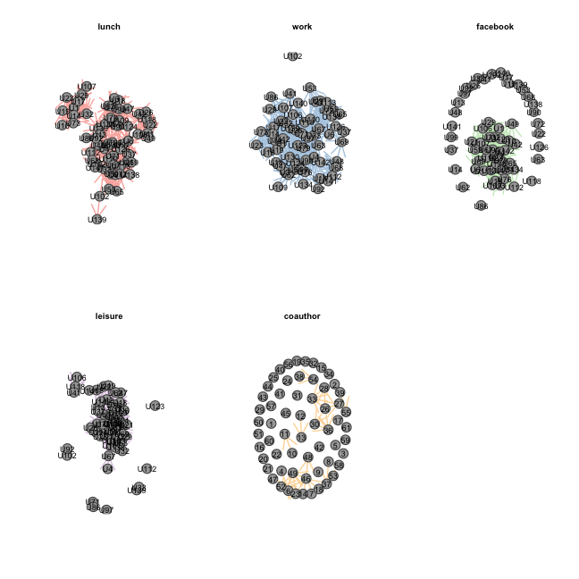

```r
library("graphsim")
library("RColorBrewer")
par(mfrow = c(2, 3))
plot_directed(multiplex_graph$lunch, main = "lunch", col.arrow = brewer.pal(5, "Pastel1")[1], layout = layout.kamada.kawai)
plot_directed(multiplex_graph$work, main = "work", col.arrow = brewer.pal(5, "Pastel1")[2], layout = layout.kamada.kawai)
plot_directed(multiplex_graph$facebook, main = "facebook", col.arrow = brewer.pal(5, "Pastel1")[3], layout = layout.kamada.kawai)
plot_directed(multiplex_graph$leisure, main = "leisure", col.arrow = brewer.pal(5, "Pastel1")[4], layout = layout.kamada.kawai)
plot_directed(multiplex_graph$coauthor, main = "coauthor", col.arrow = brewer.pal(5, "Pastel1")[5], layout = layout.kamada.kawai)
```

This data can also be represented by an adjacency matrix derived from a graph object.

```r
library("igraph")
multiplex_matrix <- lapply(multiplex_graph, igraph::as_adjacency_matrix)
multiplex_matrix
```

[output not shown]

[output cut: 583 more lines]

[output not shown]

### Running the Leiden algorithm in R

Then the Leiden algorithm can be run on the adjacency matrix using a partition type for Multiplex graphs. Here the types are computed automatically.

```r
partition <- leiden(multiplex_graph,
                       partition_type = "CPMVertexPartition",
                       resolution_parameter = 0.025,
                       seed = 9001)


























table(partition)
```

```
#> partition
#>  1  2  3  4  5
#> 34 12  8  6  1
```

Here we can see that the partitions are defined across all graphs in the list.

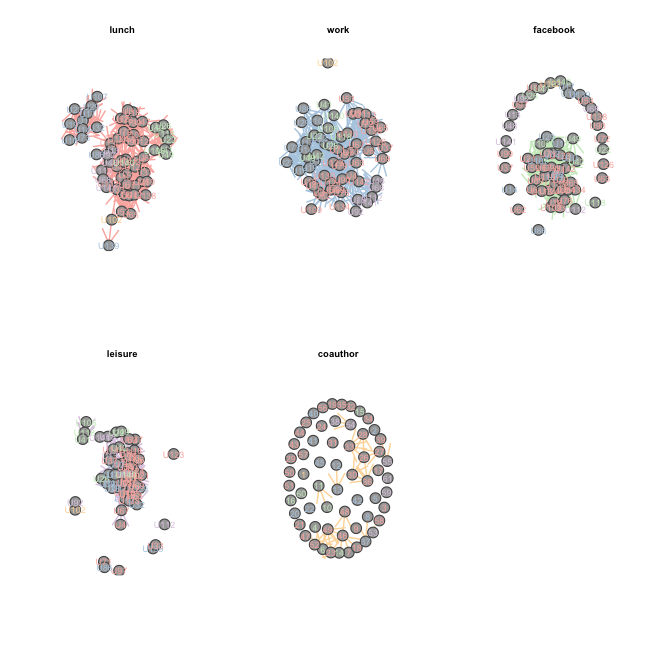

```r
library("graphsim")
library("RColorBrewer")
node.cols <- brewer.pal(max(c(10, partition)),"Pastel1")[partition]
par(mfrow = c(2, 3))
plot_directed(multiplex_graph$lunch, main = "lunch", col.label  = node.cols, col.arrow = brewer.pal(5, "Pastel1")[1], layout = layout.kamada.kawai)
plot_directed(multiplex_graph$work, main = "work", col.label  = node.cols, col.arrow = brewer.pal(5, "Pastel1")[2], layout = layout.kamada.kawai)
plot_directed(multiplex_graph$facebook, main = "facebook", col.label  = node.cols, col.arrow = brewer.pal(5, "Pastel1")[3], layout = layout.kamada.kawai)
plot_directed(multiplex_graph$leisure, main = "leisure", col.label  = node.cols, col.arrow = brewer.pal(5, "Pastel1")[4], layout = layout.kamada.kawai)
plot_directed(multiplex_graph$coauthor, main = "coauthor", col.label  = node.cols, col.arrow = brewer.pal(5, "Pastel1")[5], layout = layout.kamada.kawai)
```

This can also be run on a list of adjacency matrices giving the same results.

```r
partition <- leiden(multiplex_matrix,
                       partition_type = "CPMVertexPartition",
                       resolution_parameter = 0.025,
                       seed = 9001)
```

[output not shown]

```r
table(partition)
```

```
#> partition
#>  1  2  3  4  5
#> 34 12  8  6  1
```

### Fine-tuning with resolution

The resolution parameter applies on multiplex graphs to fine-tuning how many clusters are detected.

```r
partition <- leiden(multiplex_graph, partition_type = "CPMVertexPartition", resolution_parameter = 0.1, seed = 42)


























table(partition)
```

```
#> partition
#>  1  2  3  4  5  6  7  8  9 10
#> 14 11 11  8  7  4  3  1  1  1
```

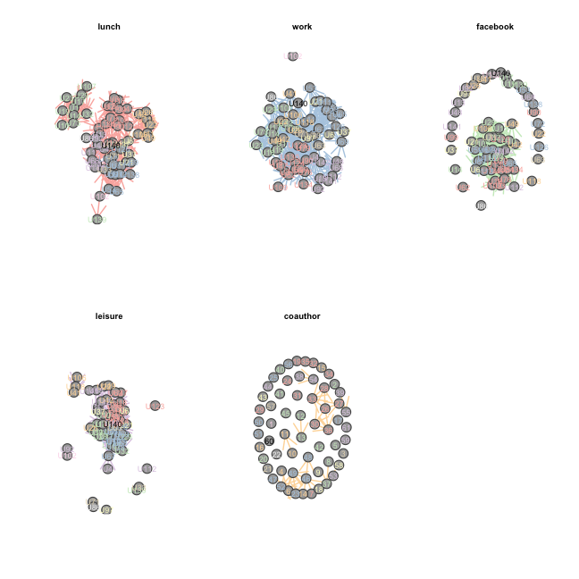

```r
library("graphsim")
library("RColorBrewer")
node.cols <- brewer.pal(max(c(10, partition)),"Pastel1")[partition]
par(mfrow = c(2, 3))
plot_directed(multiplex_graph$lunch, main = "lunch", col.label  = node.cols, col.arrow = brewer.pal(5, "Pastel1")[1], layout = layout.kamada.kawai)
plot_directed(multiplex_graph$work, main = "work", col.label  = node.cols, col.arrow = brewer.pal(5, "Pastel1")[2], layout = layout.kamada.kawai)
plot_directed(multiplex_graph$facebook, main = "facebook", col.label  = node.cols, col.arrow = brewer.pal(5, "Pastel1")[3], layout = layout.kamada.kawai)
plot_directed(multiplex_graph$leisure, main = "leisure", col.label  = node.cols, col.arrow = brewer.pal(5, "Pastel1")[4], layout = layout.kamada.kawai)
plot_directed(multiplex_graph$coauthor, main = "coauthor", col.label  = node.cols, col.arrow = brewer.pal(5, "Pastel1")[5], layout = layout.kamada.kawai)
```

### Fine-tuning with maximum community size

```r
partition <- leiden(multiplex_graph, partition_type = "CPMVertexPartition", max_comm_size = 8, resolution_parameter = 0.1, seed = 42)


























table(partition)
```

```
#> partition
#>  1  2  3  4  5  6  7  8  9 10 11 12
#>  8  8  8  7  7  6  5  5  4  1  1  1
```

[figure not shown]

```r
library("graphsim")
library("RColorBrewer")
node.cols <- brewer.pal(max(c(10, partition)),"Pastel1")[partition]
par(mfrow = c(2, 3))
plot_directed(multiplex_graph$lunch, main = "lunch", col.label  = node.cols, col.arrow = brewer.pal(5, "Pastel1")[1], layout = layout.kamada.kawai)
plot_directed(multiplex_graph$work, main = "work", col.label  = node.cols, col.arrow = brewer.pal(5, "Pastel1")[2], layout = layout.kamada.kawai)
plot_directed(multiplex_graph$facebook, main = "facebook", col.label  = node.cols, col.arrow = brewer.pal(5, "Pastel1")[3], layout = layout.kamada.kawai)
plot_directed(multiplex_graph$leisure, main = "leisure", col.label  = node.cols, col.arrow = brewer.pal(5, "Pastel1")[4], layout = layout.kamada.kawai)
plot_directed(multiplex_graph$coauthor, main = "coauthor", col.label  = node.cols, col.arrow = brewer.pal(5, "Pastel1")[5], layout = layout.kamada.kawai)
```

### Multiplex cost functions

Any defined cost function is supported for multiplex graphs. For example, the Modularity Vertex Partition is also supported.

```r
partition <- leiden(multiplex_graph, partition_type = "ModularityVertexPartition", resolution_parameter = 0.02, seed = 42)


























table(partition)
```

```
#> partition
#>  1  2  3  4  5  6
#> 15 13 13 11  8  1
```

Here we can see partitions in the plotted results are different to as those computed above.

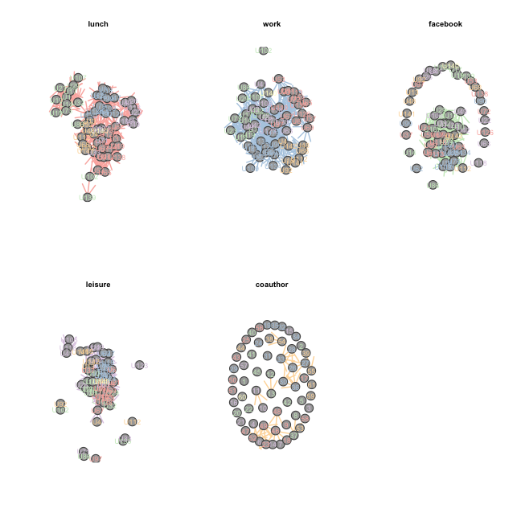

```r
library("graphsim")
library("RColorBrewer")
node.cols <- brewer.pal(max(c(8, partition)),"Pastel1")[partition]
par(mfrow = c(2, 3))
plot_directed(multiplex_graph$lunch, main = "lunch", col.label  = node.cols, col.arrow = brewer.pal(5, "Pastel1")[1], layout = layout.kamada.kawai)
plot_directed(multiplex_graph$work, main = "work", col.label  = node.cols, col.arrow = brewer.pal(5, "Pastel1")[2], layout = layout.kamada.kawai)
plot_directed(multiplex_graph$facebook, main = "facebook", col.label  = node.cols, col.arrow = brewer.pal(5, "Pastel1")[3], layout = layout.kamada.kawai)
plot_directed(multiplex_graph$leisure, main = "leisure", col.label  = node.cols, col.arrow = brewer.pal(5, "Pastel1")[4], layout = layout.kamada.kawai)
plot_directed(multiplex_graph$coauthor, main = "coauthor", col.label  = node.cols, col.arrow = brewer.pal(5, "Pastel1")[5], layout = layout.kamada.kawai)
```